# Class Analysis for LING 343

Author

Boyan Wu

Published

March 30, 2023

# Read in Data

Create dataframes from the three rds files in the data folder.

```r
df_compq <- read_rds(here("data", "df_compq.rds"))
df_demo <- read_rds(here("data", "df_demo.rds"))
df_sprt <- read_rds(here("data", "df_sprt.rds"))
```

For each participant, get percent accuracy for comprehension questions # Participant Accuracy Check

```r
df_compq %>%
  group_by(iphash) %>%
  summarize(
    accuracy = sum(correct1)/n()*100
  )
```

```
# A tibble: 79 × 2
   iphash                           accuracy
   <chr>                               <dbl>
 1 01be579c483b17df05317ad154b84dfa     89.8
 2 023ba0c7c1b39912063c6dd84cbd9acc     83.0
 3 0250bdac435520d69c2cf494dcce5edb     88.6
 4 03ca5a49fd8116e51b8596baecd99ff3     80.7
 5 07f041aeee9dc6cff162eff594829469     80.7
 6 0a4c95ef5f90b49c74e63b85cbdbdf98     88.6
 7 0ced8b1c21c7eefc84391c7691bf4be1     80.7
 8 0e855ee3316b9c1938d50a5d73d58071     77.3
 9 179b6cda4735bda1544f2f596a1270c6     84.1
10 21f70b5021f20f86c544dc48da93a5d5     97.7
# … with 69 more rows
```

# Combine Stimuli Information

Add the information about each stimulus sentence from the stimuli file to the self-paced reading data. They should have matching label variables.

```r
df_stims <- read.csv(here("stimuli", "stimuli-2023-eventive-repl-sprt.csv"))

df_sprt_joined <- left_join(df_sprt,
                            select(df_stims, -sentence),
                            join_by(label))

df_sprt %>% filter(label == "gp.state.201")
```

```
# A tibble: 390 × 19
    expsubmit iphash ibexc…¹ ibex_…² ibex_…³ label group contr…⁴ penn_…⁵ word_…⁶
        <dbl> <chr>  <chr>     <dbl>   <dbl> <chr> <chr> <chr>   <chr>   <chr>
 1 1680113433 247e2… PennCo…     705       0 gp.s… 2     Contro… Dashed… 1
 2 1680113433 247e2… PennCo…     705       0 gp.s… 2     Contro… Dashed… 2
 3 1680113433 247e2… PennCo…     705       0 gp.s… 2     Contro… Dashed… 3
 4 1680113433 247e2… PennCo…     705       0 gp.s… 2     Contro… Dashed… 4
 5 1680113433 247e2… PennCo…     705       0 gp.s… 2     Contro… Dashed… 5
 6 1680113433 247e2… PennCo…     705       0 gp.s… 2     Contro… Dashed… 6
 7 1680113433 247e2… PennCo…     705       0 gp.s… 2     Contro… Dashed… 7
 8 1680113433 247e2… PennCo…     705       0 gp.s… 2     Contro… Dashed… 8
 9 1680113433 247e2… PennCo…     705       0 gp.s… 2     Contro… Dashed… 9
10 1680113433 247e2… PennCo…     705       0 gp.s… 2     Contro… Dashed… 10
# … with 380 more rows, 9 more variables: word <chr>, event_time <chr>,
#   counter <chr>, label2 <chr>, latinitem <chr>, RT <dbl>, newlineTF <chr>,
#   sentence <chr>, comments <chr>, and abbreviated variable names
#   ¹ibexcontrol, ²ibex_item_num, ³ibex_elem_num, ⁴controller2,
#   ⁵penn_elem_name, ⁶word_num
```

## Count Stimuli Per Condition

The first condition column in the stimuli labels the experiment. For the experiment labelled “gp”, how many stimuli are there per condition?

```r
df_stims %>%
  filter(cond1 == "gp") %>%
  group_by(cond2) %>%
  count()
```

```
# A tibble: 2 × 2
# Groups:   cond2 [2]
  cond2     n
  <chr> <int>
1 event    44
2 state    44
```

How many stimuli are there per item?

```r
df_stims %>%
  filter(cond1 == "gp") %>%
  group_by(item) %>%
  count()
```

```
# A tibble: 44 × 2
# Groups:   item [44]
    item     n
   <int> <int>
 1   200     2
 2   201     2
 3   202     2
 4   203     2
 5   204     2
 6   205     2
 7   206     2
 8   207     2
 9   208     2
10   209     2
# … with 34 more rows
```

Answer these questions for the “mklo” stimuli.

```r
df_stims %>%
  filter(cond1 == "mklo") %>%
  group_by(cond2) %>%
  count()
```

```
# A tibble: 2 × 2
# Groups:   cond2 [2]
  cond2     n
  <chr> <int>
1 break    12
2 hit      12
```

```r
df_stims %>%
  filter(cond1 == "mklo") %>%
  group_by(item) %>%
  count()
```

```
# A tibble: 12 × 2
# Groups:   item [12]
    item     n
   <int> <int>
 1   100     2
 2   101     2
 3   102     2
 4   103     2
 5   104     2
 6   105     2
 7   106     2
 8   107     2
 9   108     2
10   109     2
11   110     2
12   111     2
```

# McKoon and Love 2011 Replication

The “mklo” stimuli are from the study McKoon and Love 2011. They found that result (“break”) verbs had longer reaction times than manner (“hit”) verbs. The verb is the third word in each sentence. Was their effect replicated in this experiment? Let’s take some steps to see.

McKoon, G., & Love, J. (2011). Verbs in the lexicon: Why is hitting easier than breaking? Language and Cognition, 3, 313–330. https://doi.org/10.1515/LANGCOG.2011.011

## Summaries

For visualization and basic summary statistics, where participants are exposed to repeated measures, we usually calculate averages for each participant first. We want the average for each participant for each condition, so averaging “over” all of the items they saw in that condition. But remember we want to separate the times for each word, and we are mainly interested in the verb (word 3).

```r
df_sprt_joined %>%
  filter(cond1 == "mklo" & word_num %in% c("2", "3", "4")) %>%
  group_by(iphash, cond2, word_num) %>%
  summarize(
    mean = mean(RT, na.rm=TRUE)
  )
```

```
# A tibble: 474 × 4
# Groups:   iphash, cond2 [158]
   iphash                           cond2 word_num  mean
   <chr>                            <chr> <chr>    <dbl>
 1 01be579c483b17df05317ad154b84dfa break 2         292
 2 01be579c483b17df05317ad154b84dfa break 3         333.
 3 01be579c483b17df05317ad154b84dfa break 4         321.
 4 01be579c483b17df05317ad154b84dfa hit   2         311.
 5 01be579c483b17df05317ad154b84dfa hit   3         306.
 6 01be579c483b17df05317ad154b84dfa hit   4         343.
 7 023ba0c7c1b39912063c6dd84cbd9acc break 2         662.
 8 023ba0c7c1b39912063c6dd84cbd9acc break 3         634.
 9 023ba0c7c1b39912063c6dd84cbd9acc break 4         617.
10 023ba0c7c1b39912063c6dd84cbd9acc hit   2         470.
# … with 464 more rows
```

Then, we average those averages to get a condition mean. Did break verbs take longer than hit verbs?

Try printing your output as a formatted table by piping the dataframe/tibble to the function `kableExtra::kbl()`. You may need to first install the package `{kableExtra}` from CRAN.

```r
library(kableExtra)
df_means <- df_sprt_joined %>%
  filter(cond1 == "mklo" & word_num %in% c("2", "3", "4")) %>%
  group_by(iphash, cond2, word_num) %>%
  summarize(
    mean = mean(RT, na.rm=TRUE)
  )
df_cond_means <- df_means %>%
  group_by(cond2, word_num) %>%
  summarize(
    mean = mean(mean)
  ) %>%
  pivot_wider(
    names_from = cond2,
    values_from = mean
  ) %>%
  mutate(
    difference = `break` - `hit`
  )
kbl(df_cond_means, caption = "Condition means for hit vs. break verbs")
```

Condition means for hit vs. break verbs

| word_num | break | hit | difference |
| --- | --- | --- | --- |
| 2 | 451.3312 | 423.2975 | 28.03376 |
| 3 | 503.1139 | 472.1287 | 30.98523 |
| 4 | 434.4409 | 414.1181 | 20.32278 |

## Plots

Make a plot showing the means for both conditions for word 3.

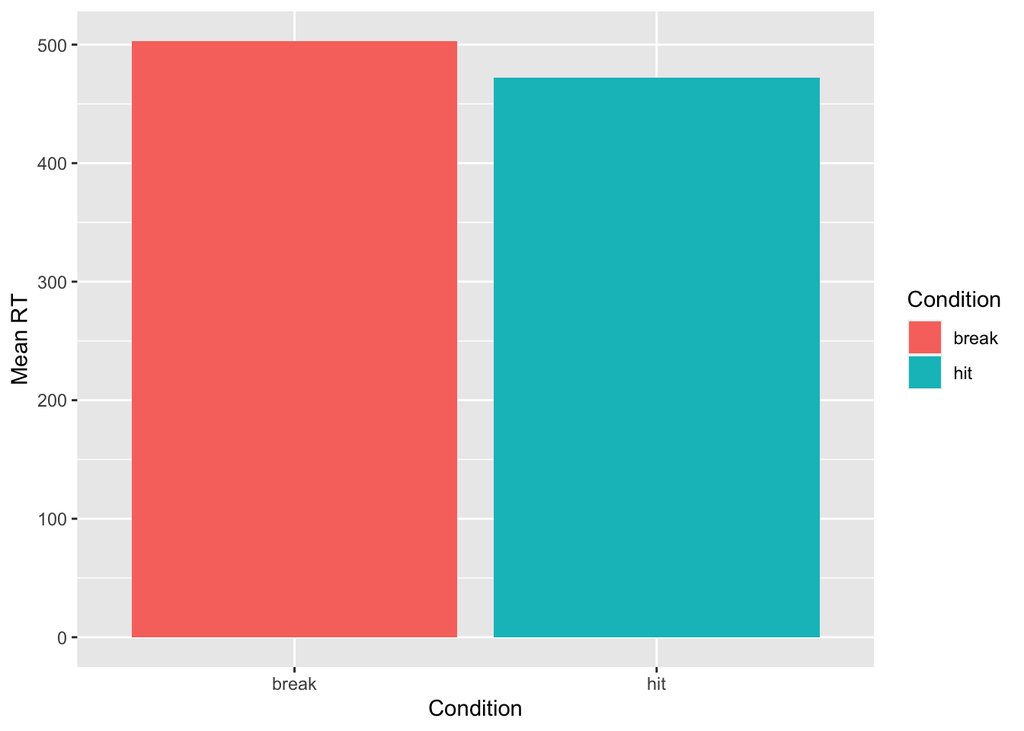

```r
library(ggplot2)

df_means <- df_sprt_joined %>%
  filter(cond1 == "mklo" & word_num %in% "3") %>%
  group_by(cond2, word_num) %>%
  summarize(
    mean_RT = mean(RT, na.rm = TRUE)
  )
ggplot(df_means, aes(x = cond2, y = mean_RT, fill = cond2)) +
  geom_bar(stat = "identity", position = "dodge") +
  labs(x = "Condition", y = "Mean RT", fill = "Condition")
```

Now add words 2 and 4 also. Can you put them in one faceted plot?

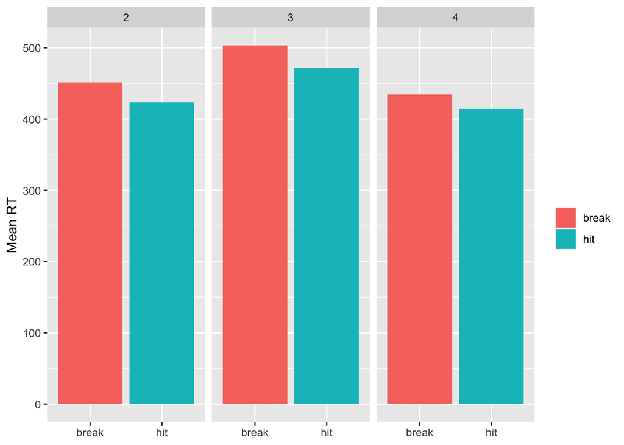

```r
df_means <- df_sprt_joined %>%
  filter(cond1 == "mklo" & word_num %in% c("2", "3", "4")) %>%
  group_by(cond2, word_num) %>%
  summarize(
    mean_RT = mean(RT, na.rm = TRUE)
  )
ggplot(df_means, aes(x = cond2, y = mean_RT, fill = cond2)) +
  geom_bar(stat = "identity", position = "dodge") +
  labs(x = NULL, y = "Mean RT", fill = NULL) +
  facet_wrap(~word_num)
```

# Gennari and Poeppel 2003 Replication

The “gp” stimuli are from the study Gennari and Poeppel 2003. They found that eventive verbs had longer RTs than stative verbs. The verb is the fourth word in these sentences. Was their effect replicated? Try the same steps.

Gennari, S., & Poeppel, D. (2003). Processing correlates of lexical semantic complexity. Cognition, 89(1), B27–B41. https://doi.org/10.1016/S0010-0277(03)00069-6

```r
df_stims %>%
  filter(cond1 == "gp") %>%
  group_by(cond2) %>%
  count()
```

```
# A tibble: 2 × 2
# Groups:   cond2 [2]
  cond2     n
  <chr> <int>
1 event    44
2 state    44
```

```r
df_stims %>%
  filter(cond1 == "gp") %>%
  group_by(item) %>%
  count()
```

```
# A tibble: 44 × 2
# Groups:   item [44]
    item     n
   <int> <int>
 1   200     2
 2   201     2
 3   202     2
 4   203     2
 5   204     2
 6   205     2
 7   206     2
 8   207     2
 9   208     2
10   209     2
# … with 34 more rows
```

## Summaries

```r
df_sprt_joined %>%
  filter(cond1 == "gp" & word_num %in% c("2", "3", "4")) %>%
  group_by(iphash, cond2, word_num) %>%
  summarize(
    mean = mean(RT, na.rm=TRUE)
  )
```

```
# A tibble: 474 × 4
# Groups:   iphash, cond2 [158]
   iphash                           cond2 word_num  mean
   <chr>                            <chr> <chr>    <dbl>
 1 01be579c483b17df05317ad154b84dfa event 2         375.
 2 01be579c483b17df05317ad154b84dfa event 3         291.
 3 01be579c483b17df05317ad154b84dfa event 4         397
 4 01be579c483b17df05317ad154b84dfa state 2         303
 5 01be579c483b17df05317ad154b84dfa state 3         345.
 6 01be579c483b17df05317ad154b84dfa state 4         335.
 7 023ba0c7c1b39912063c6dd84cbd9acc event 2        1076.
 8 023ba0c7c1b39912063c6dd84cbd9acc event 3        1068.
 9 023ba0c7c1b39912063c6dd84cbd9acc event 4         767.
10 023ba0c7c1b39912063c6dd84cbd9acc state 2         892.
# … with 464 more rows
```

```r
library(kableExtra)
df_means <- df_sprt_joined %>%
  filter(cond1 == "gp" & word_num %in% c("2", "3", "4")) %>%
  group_by(iphash, cond2, word_num) %>%
  summarize(
    mean = mean(RT, na.rm=TRUE)
  )
df_cond_means <- df_means %>%
  group_by(cond2, word_num) %>%
  summarize(
    mean = mean(mean)
  ) %>%
  pivot_wider(
    names_from = cond2,
    values_from = mean
  ) %>%
  mutate(
    difference = `event` - `state`
  )
kbl(df_cond_means, caption = "Condition means for eventive vs. stative verbs")
```

Condition means for eventive vs. stative verbs

| word_num | event | state | difference |
| --- | --- | --- | --- |
| 2 | 466.2146 | 468.9217 | -2.707135 |
| 3 | 513.2940 | 519.3072 | -6.013234 |
| 4 | 524.8665 | 532.6335 | -7.766973 |

## Plots

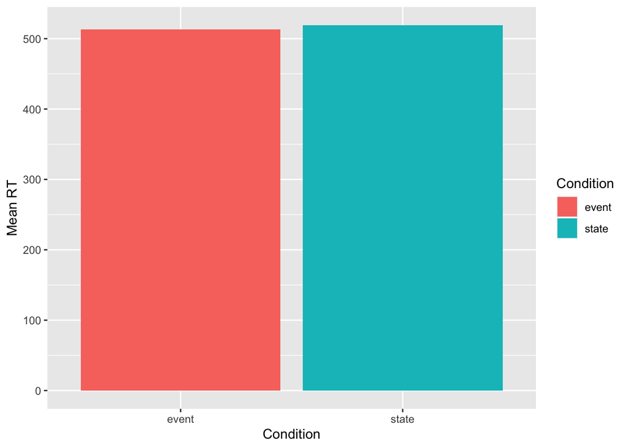

```r
library(ggplot2)

df_means <- df_sprt_joined %>%
  filter(cond1 == "gp" & word_num %in% "3") %>%
  group_by(cond2, word_num) %>%
  summarize(
    mean_RT = mean(RT, na.rm = TRUE)
  )
ggplot(df_means, aes(x = cond2, y = mean_RT, fill = cond2)) +
  geom_bar(stat = "identity", position = "dodge") +
  labs(x = "Condition", y = "Mean RT", fill = "Condition")
```

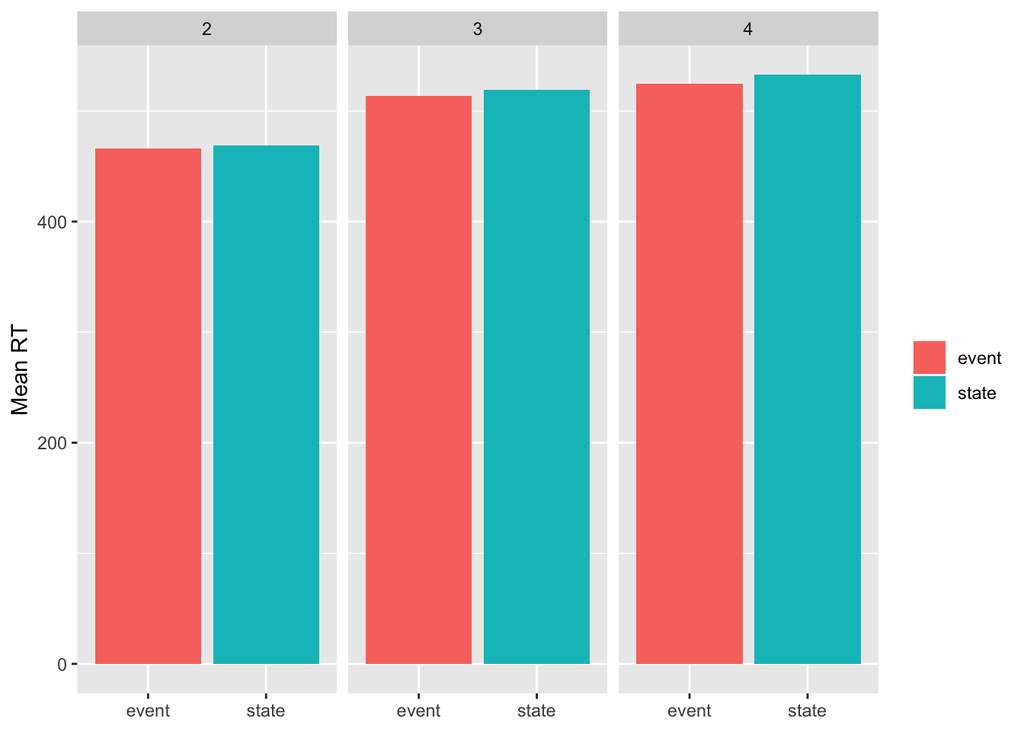

```r
df_means <- df_sprt_joined %>%
  filter(cond1 == "gp" & word_num %in% c("2", "3", "4")) %>%
  group_by(cond2, word_num) %>%
  summarize(
    mean_RT = mean(RT, na.rm = TRUE)
  )
ggplot(df_means, aes(x = cond2, y = mean_RT, fill = cond2)) +
  geom_bar(stat = "identity", position = "dodge") +
  labs(x = NULL, y = "Mean RT", fill = NULL) +
  facet_wrap(~word_num)
```